# Анализ влияния аварии на АЭС Фукусима-1 на содержание радиоактивных веществ в воздухе Канады.

Гаджиев Фарид

## Введение.

Было проведено исследование данных количества радиоактивных нуклидов в воздухе Канады. Данные, использованные в исследовании, были взяты с [сайта Канадского правительства](http://open.canada.ca/)[^1].

Представленные данные содержат информацию о концентрации, степени неопределенности и минимальную обнаруживаемую концентрацию для следующих радиоактивных нуклидов: Бериллий-7 (Be7), Свинец-210 (Pb210), Цезий-134 (Cs134), Цезий-137 (Cs137) и Йод-131 (I131).

## Цель работы.

Целью данной работы было изучение влияния катастрофы на АЭС Фукусима-1 в марте 2011 года на концентрацию радиоактивных элементов в воздухе Канады.

## Анализ результатов.

Ниже представлены графики зависимости концентрации вышеуказанных радионуклидов в воздухе от времени. Кроме того, на всех графиках красным пунктиром указана дата катастрофы на АЭС Фукусима-1.

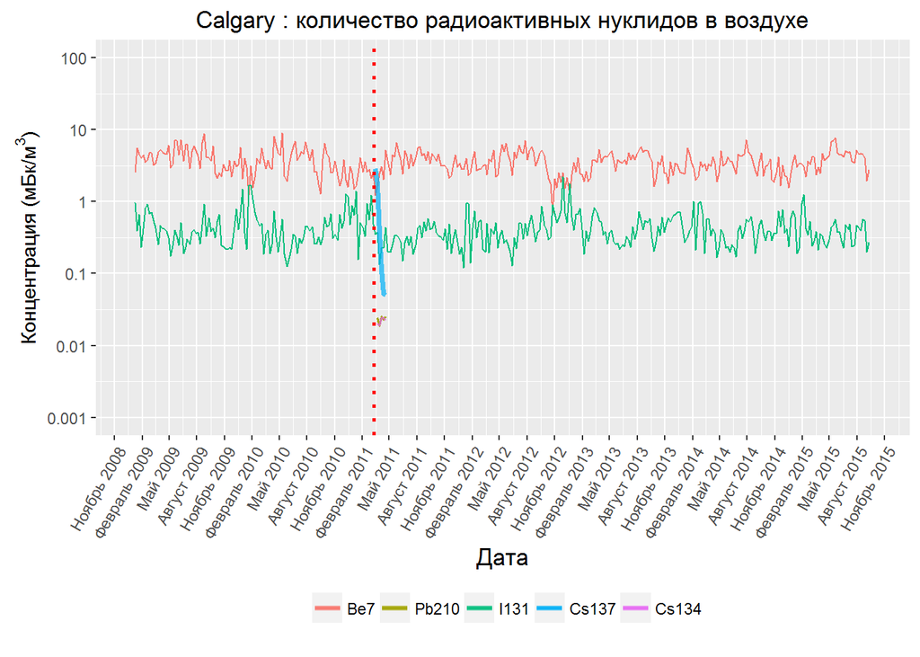

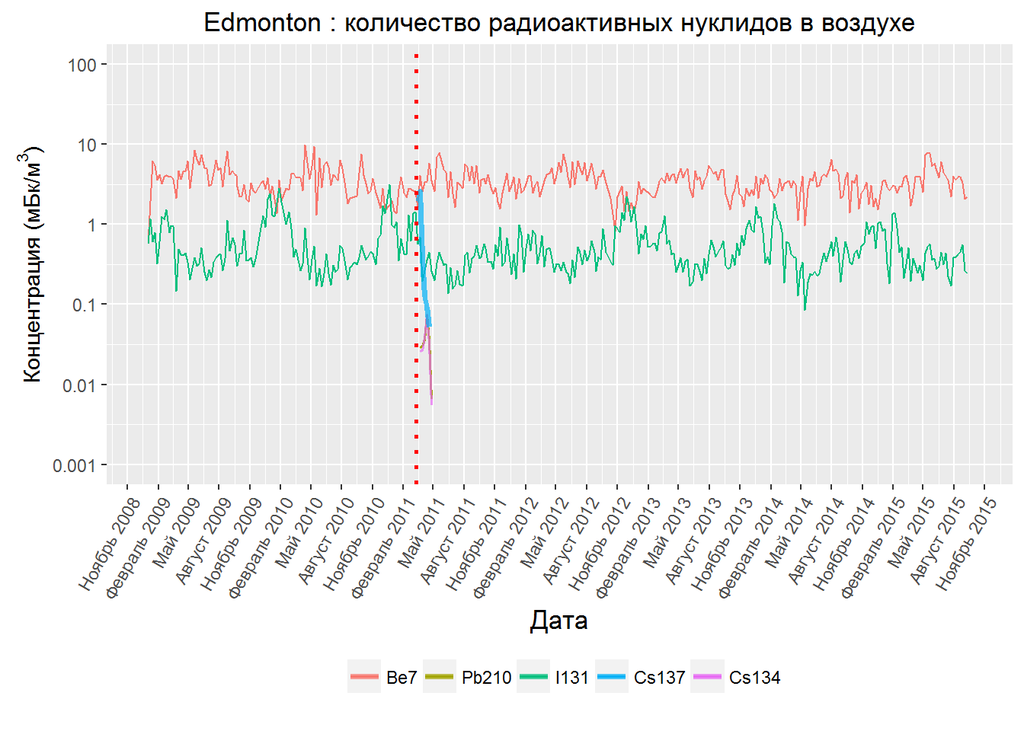

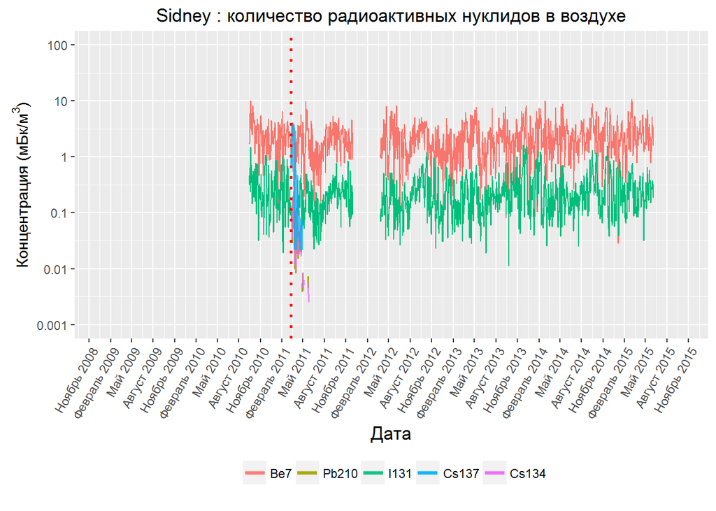

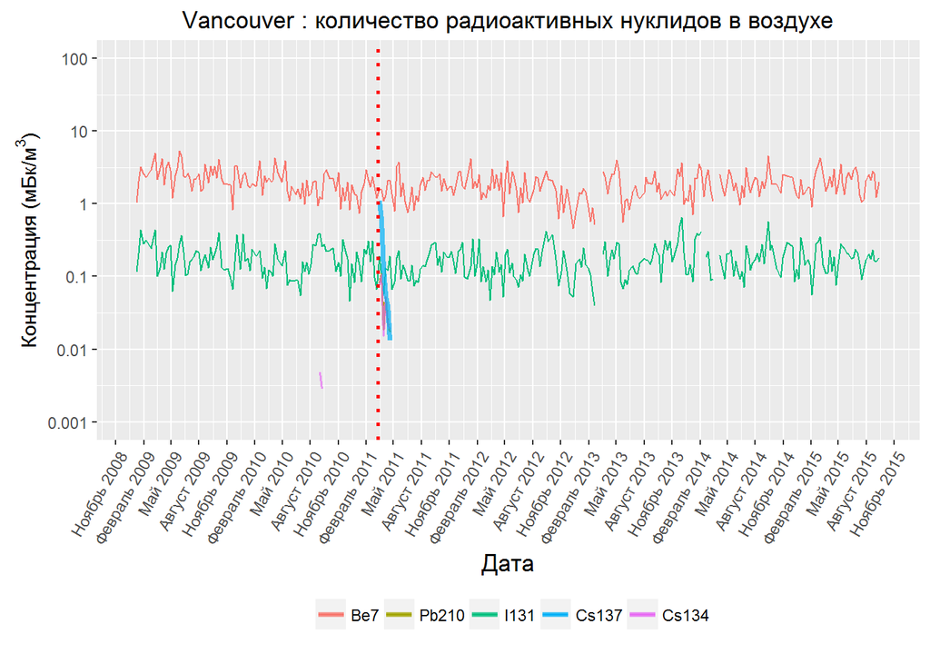

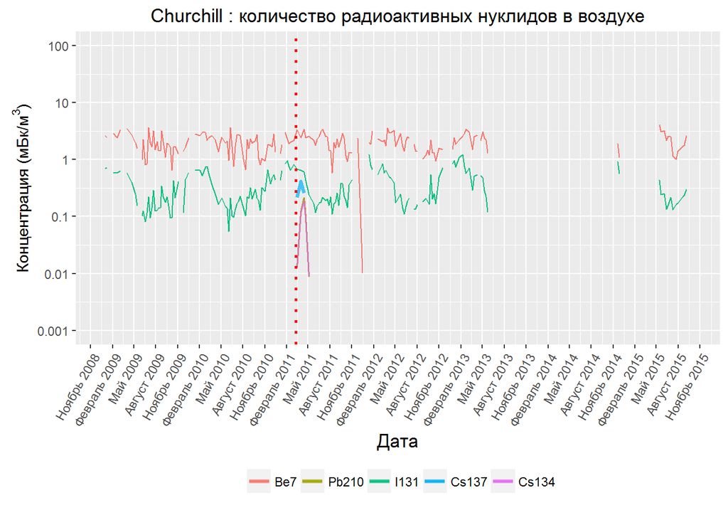

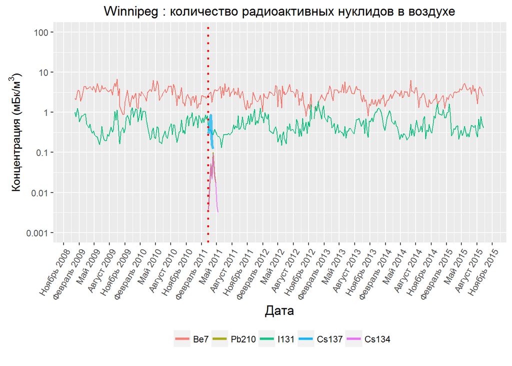

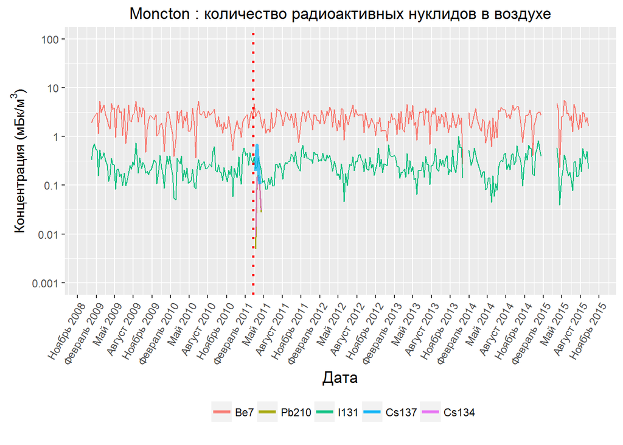

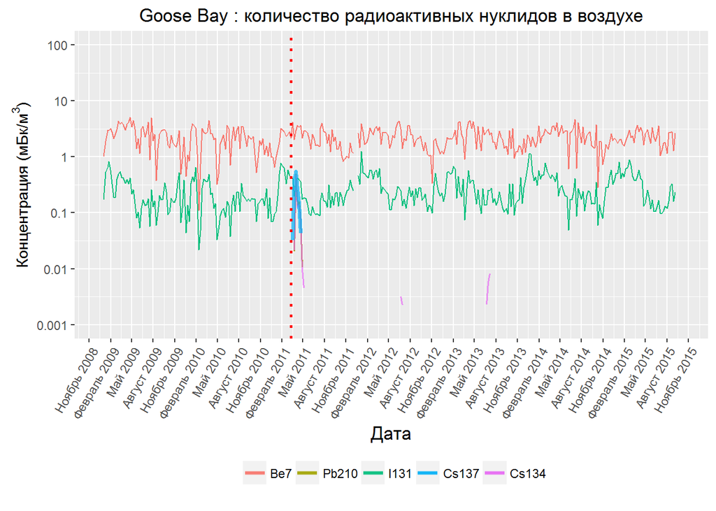

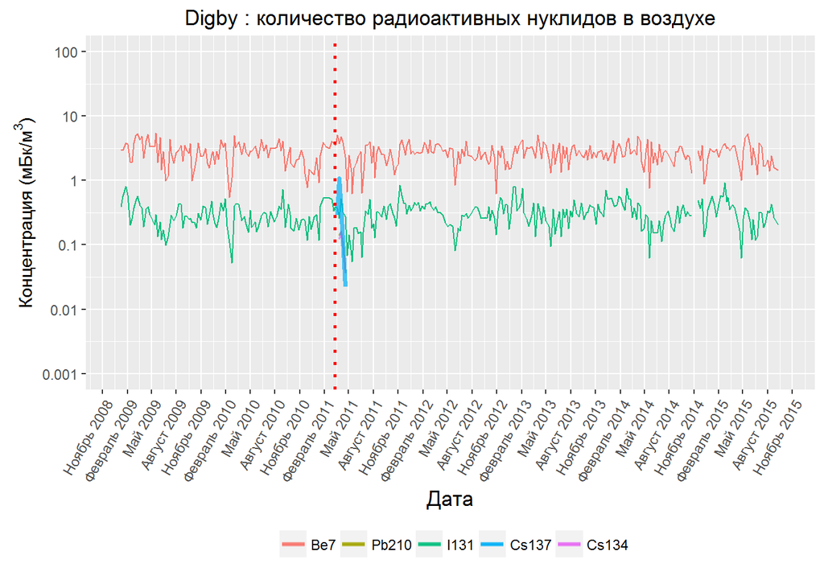

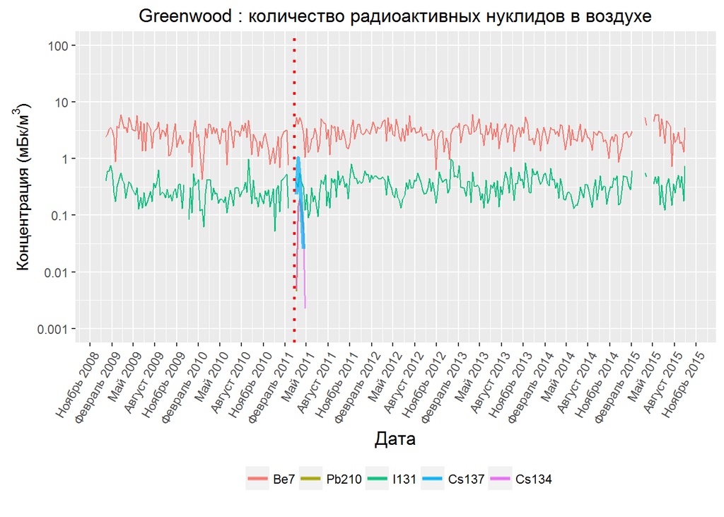

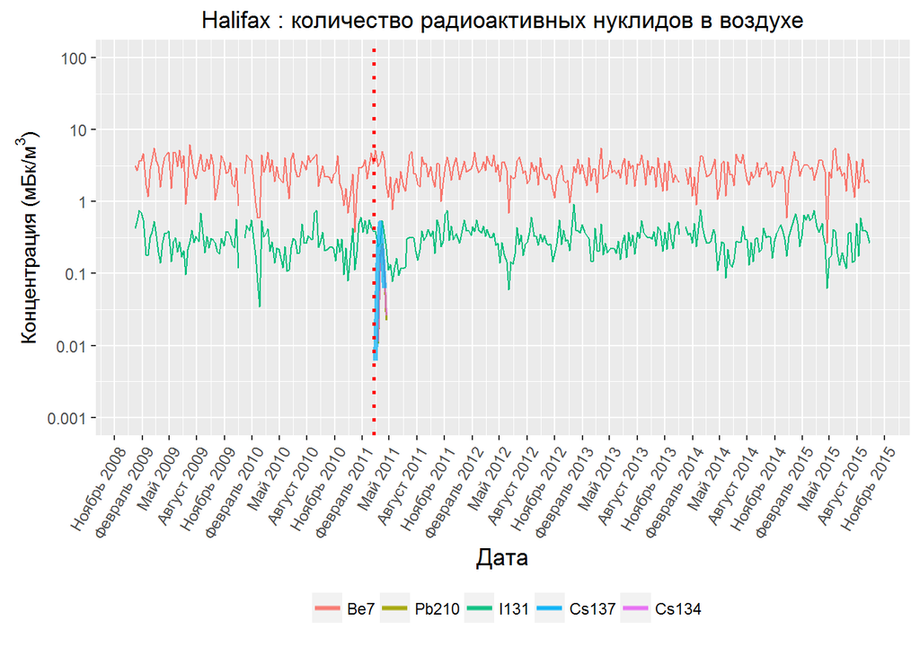

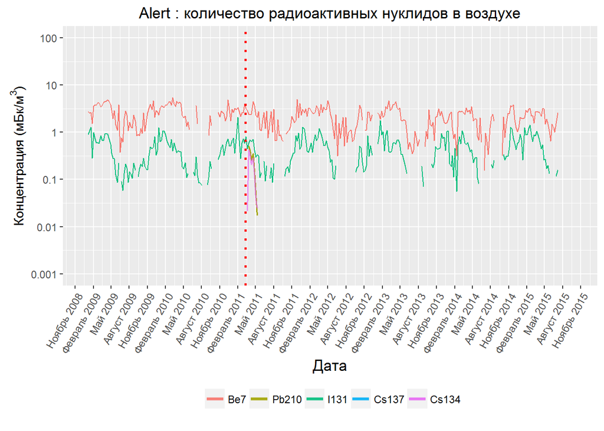

[17 more figures not shown]

[^1]: [Прямая ссылка на данные](http://www.hc-sc.gc.ca/data-donnees/hecs-dgsesc/nms_airborne_radioactivity_ssn_radioactivite_dans_air.csv)